# dispRity manual

#### Summarising and displaying the results

Now let’s summarise this data:

```r
## Summary table of the data
summary(disparity)
```

```
##   subsamples  n   obs bs.median  2.5%   25%   75% 97.5%
## 1    Treat.a 21 36.89     35.01 31.32 32.88 35.44 36.11
## 2    Treat.a 17    NA     33.69 30.38 31.91 34.97 35.98
## 3    Treat.b 19 40.99     38.19 34.27 36.75 39.25 40.12
## 4    Treat.b 17    NA     37.52 33.38 36.08 38.85 39.80
## 5    Depth.1 23 36.38     34.44 31.86 33.63 35.01 35.52
## 6    Depth.1 17    NA     33.38 30.56 32.28 34.09 35.18
## 7    Depth.2 17 40.74     37.30 34.26 36.35 38.62 39.74
```

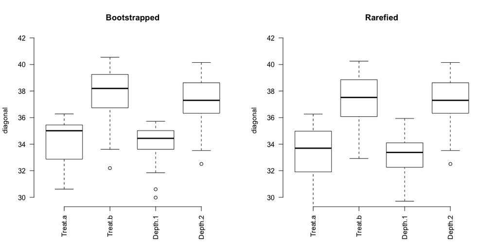

```r
## Graphical options
op <- par(mfrow = (c(1, 2)), bty = "n")

## Plotting the bootstrapped disparity
plot(disparity, main = "Bootstrapped", las = 2, xlab = "")

## Plotting the rarefied disparity
plot(disparity, rarefaction = 17, main = "Rarefied", las = 2, xlab = "")
```

```r
par(op)
```

As we can see, there seems to be no strong effect of the number of experimental plots in each subsample (i.e. the rarefied plot is really similar to the bootstrapped plot) which is a good thing!

#### Testing our hypotheses

Finally, we can test our hypothesis (whether the water treatment at certain depths alters invertebrate communities and composition in natural habitats) by using the `test.dispRity` function.

```r
## Testing the effect of treatment and depth on the bootstrapped data
summary(test.dispRity(disparity, test = aov, comparisons = "all"))
```

```
##      Length Class Mode
## [1,] 13     aov   list
```

## Simulating discrete morphological data

The `dispRity` package also allows users to simulate discrete morphological data matrices. In brief, the function `sim.morpho` takes a phylogenetic tree, the number of required characters, the evolutionary model, and a function from which to draw the rates. The package also contains a function for quickly checking the matrix’s phylogenetic signal (as defined in systematics not phylogenetic comparative methods) using parsimony. To understand these methods please refer to the phylogenetics literature.

```r
set.seed(3)
## Simulating a starting tree with 15 taxa as a random coalescent tree
my_tree <- rcoal(15)

## Generating a matrix with 100 characters (85% binary and 15% three state) and
## an equal rates model with a gamma rate distribution (0.5, 1) with no
## invariant characters.
my_matrix <- sim.morpho(tree = my_tree, characters = 100, states = c(0.85,
    0.15), rates = c(rgamma, 0.5, 1), invariant = FALSE)

## The first few lines of the matrix
my_matrix[1:5, 1:10]
```

```
##     [,1] [,2] [,3] [,4] [,5] [,6] [,7] [,8] [,9] [,10]
## t15 "1"  "1"  "0"  "1"  "1"  "2"  "1"  "1"  "0"  "0"
## t12 "1"  "1"  "0"  "1"  "1"  "2"  "1"  "1"  "0"  "0"
## t14 "1"  "1"  "0"  "1"  "1"  "2"  "1"  "1"  "0"  "0"
## t6  "1"  "1"  "0"  "1"  "1"  "2"  "1"  "1"  "0"  "0"
## t3  "0"  "0"  "1"  "0"  "1"  "0"  "0"  "2"  "1"  "0"
```

```r
## Checking the matrix properties with a quick Maximum Parsimony tree search
check.morpho(my_matrix, my_tree)
```

```
##
## Maximum parsimony        139.0000000
## Consistency index          0.7625899
## Retention index            0.8881356
## Robinson-Foulds distance   0.0000000
```

Note that this example produces a tree with a great consistency index and an identical topology to the random coalescent tree! Nearly too good to be true…

### A more detailed description

`sim.morpho` is really flexible and takes many different arguments to allow users to simulate realistic matrices. It has three implemented models: `"ER"` for Equal Rates (the M*k* model); `"HKY"`, the molecular HKY model but transforms pyrines in 0’s and pyrimidines in 1’s; or the `"mixed"` model that randomly uses an `"ER"` and/or `"HKY"` for the binary characters and `"ER"` for the multistate (>2) characters. Both models take specific distributions for their rate or substitution models. These distributions should be passed to these arguments in the format of `c(sampler_function, distribution_parameters)` where the the sampler function is a the random generation function of that distribution (e.g. `rnorm`, `runif`, etc…) and the parameters are any parameters to be passed to this function.

`check.morpho` runs a quick Maximum Parsimony tree search using the `phangorn` parsimony algorithm. It quickly calculates the parsimony score, the consistency and retention indices and, if a tree is provided (e.g. the tree used to generate the matrix) it calculates the Robinson-Foulds distance between the most parsimonious tree and the provided tree to determine how different they are.

### Parameters for a realistic(ish) matrix

There are many parameters that can create a `realistic'' matrix (i.e. not too different from the input tree with a consistency and retention index close to what is seen in the literature) but because of the randomness of the matrix generation not all end up creating "good" matrices. The following parameters however, seem to generate fairly`realistic’’ matrices with a starting coalescent tree, equal rates model with 0.85 binary characters and 0.15 three state characters, a gamma distribution with a shape parameter ($\alpha$) of 5 and no scaling ($\beta$ = 1) with a rate of 100.

```r
set.seed(0)
## tree
my_tree <- rcoal(15)
## matrix
morpho_mat <- sim.morpho(my_tree, characters = 100, model = "ER",
    rates = c(rgamma, rate = 100, shape = 5), invariant = FALSE)
check.morpho(morpho_mat, my_tree)
```

[output not shown]

### `space.maker`

Another way to simulate data is to directly simulate an ordinated space with the `space.maker` function. This function allows users to simulate multidimensional spaces with a certain number of properties. It takes as arguments the number of elements (data points) and dimensions to create the space but also permits more fine tuning in the data simulation: it is possible to give a specific distribution to each dimension, provide a correlation matrix to link the dimensions or even provide an *a priori* distribution of the variance for each distributions!

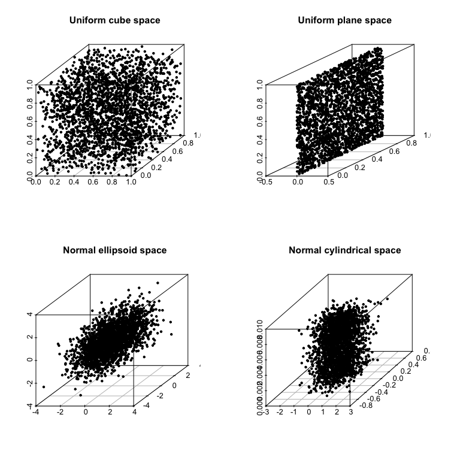

```r
## Graphical options
op <- par(mfrow = (c(2, 2)), bty = "n")
## Visualising 3D spaces
require(scatterplot3d)
## A cube space
scatterplot3d(space.maker(2500, 3, runif), pch = 20,
              xlab = "", ylab = "", zlab = "",
              main = "Uniform cube space")

## A plane space
scatterplot3d(space.maker(2500, 3, c(runif, runif, runif),
              arguments = list(list(min = 0, max = 0), NULL, NULL)), pch = 20,
              xlab = "", ylab = "", zlab = "",
              main = "Uniform plane space")

## An ellipsoid space (=a spheric space with correlation)
cor_matrix <- matrix(cbind(1, 0.8, 0.2, 0.8, 1, 0.7, 0.2, 0.7, 1), nrow = 3)
scatterplot3d(space.maker(2500, 3, rnorm, cor.matrix = cor_matrix), pch = 20,
              xlab = "", ylab = "", zlab = "",
              main = "Normal ellipsoid space")

## A cylindrical space with a decreasing variance per axis
scatterplot3d(space.maker(2500, 3, c(rnorm, rnorm, runif),
              scree = c(0.7, 0.2, 0.1)), pch = 20,
              xlab = "", ylab = "", zlab = "",
              main = "Normal cylindrical space")
```

```r
## Resetting the graphic parameters
par(op)
```

# Glossary

- **Ordinated space**. The mathematical multidimensional object that will be analysed with this package. In morphometrics, this is often referred to as the morphospace. However it may also be referred to as the cladisto-space for cladistic data or the eco-space for ecological data etc. In practice, this term designates an ordinated matrix where the columns represent the dimensions of the space (often – but not necessarily - > 3!) and the rows represent the elements within this space.
- **Elements**. The rows of the ordinated space. Elements can be taxa, field sites, countries etc.
- **Dimensions**. The columns of the ordinated space. The dimensions are referred to as axes of variation, or principal components, for ordinated spaces obtained from a PCA.
- **Subsamples**. Sub-samples of the ordinated space. A sub-sample (or subsamples) contains the same number of dimensions as the ordinated space but may contain a smaller subset of elements. For example, if our ordinated space is composed of birds and mammals (the elements) and 50 principal components (the dimensions), we can create two subsamples containing just mammals or birds, but with the same 50 dimensions, to compare disparity in the two clades.